# Sexual dimorphism in Chinstrap penguins”

### expression with table

```r
penspc = c("Pygoscelis antarctica", "Pygoscelis adeliae", "Pygoscelis papua")
bspc = c(penspc,pspc,sspc)
bmf = c(bmass.f,pbmf,sbmf)
bmm = c(bmass.m,pbmm,sbmm)
bmsdi = c(bmass.sdi,pbmsdi,sbmsdi)
wlf = c(flen.f,pwlf,swlf)
wlm = c(flen.m,pwlm,swlm)
wlsdi = c(flen.sdi,pwlsdi,swlsdi)
bias = c("Male biased","Male biased","Male biased","Female biased","Female biased",
         "Female biased","Female biased","Female biased","Female biased","Female biased",
         "Female biased","Female biased","Female biased","Female biased","Female biased",
         "Male biased","Female biased","Female biased","Male biased","Male biased",
         "Male biased","Male biased","Male biased","Male biased","Male biased","Male biased",
         "Male biased","Male biased","Male biased","Male biased","Male biased")
bird = data.frame(bspc,bmf,bmm,bmsdi,wlf,wlm,wlsdi,bias)
```

```r
kable(sdi.table, col.names=c('Species',"BM F","BM M","BM SDI","BL F","BL M","BL SDI", "BD F","BD M", "BD SDI", "FL F","FL M","FL SDI"),
      digits = 3,valign='t',
      caption="Table of measurements and SDI value of penguin species")
```

Table of measurements and SDI value of penguin species

[output not shown]

BM, BL, BD and FL stand for body mass, bill length, bill depth and filpper length respectively.

### Comparison with other bird species

The data for different avian species were sourced from the database provided by Valcu, M., Valcu, C., & Kempenaers, B. (2023). This dataset encompasses information on body mass, wing length, and Sexual Dimorphism Index (SDI) categorized by male and female specimens for various avian species. Given that the database includes statistical values for wing length and body mass, we can compare these metrics with the corresponding flipper length and body mass of the penguins in our dataset. This enables a meaningful assessment of the morphological sexual dimorphism of penguins in relation to the broader avian species data provided.

```r
kable(bird, col.names = c('Species','BM F', 'BM M', 'BM SDI', 'WL or FL F','WL or FL M','WL or FL SDI','Bias'),
      digits = 3, valign='t')
```

| Species | BM F | BM M | BM SDI | WL or FL F | WL or FL M | WL or FL SDI | Bias |
| --- | --- | --- | --- | --- | --- | --- | --- |
| Pygoscelis antarctica | 3527.206 | 3938.971 | 0.117 | 191.735 | 199.912 | 0.043 | Male biased |
| Pygoscelis adeliae | 3368.836 | 4043.493 | 0.200 | 187.795 | 192.411 | 0.025 | Male biased |
| Pygoscelis papua | 4679.741 | 5484.836 | 0.172 | 212.707 | 221.541 | 0.042 | Male biased |
| Aegolius funereus | 137.580 | 119.205 | -0.062 | 176.280 | 167.580 | -0.022 | Female biased |
| Circus pygargus | 370.000 | 261.000 | -0.152 | 367.230 | 360.000 | -0.009 | Female biased |
| Aquila heliaca | 3845.000 | 2585.000 | -0.172 | 614.200 | 566.130 | -0.035 | Female biased |
| Buteo galapagoensis | 1332.940 | 914.030 | -0.164 | 433.966 | 393.427 | -0.043 | Female biased |
| Buteo ridgwayi | 414.000 | 315.000 | -0.119 | 244.900 | 228.100 | -0.031 | Female biased |
| Haliaeetus albicilla | 5572.000 | 4014.000 | -0.142 | 667.670 | 612.600 | -0.037 | Female biased |
| Falco columbarius | 218.000 | 163.000 | -0.126 | 219.360 | 197.990 | -0.045 | Female biased |
| Falco naumanni | 164.000 | 141.000 | -0.066 | 237.330 | 235.800 | -0.003 | Female biased |
| Falco sparverius | 120.401 | 106.152 | -0.055 | 188.030 | 179.950 | -0.019 | Female biased |
| Falco tinnunculus | 201.000 | 167.000 | -0.080 | 249.130 | 237.410 | -0.021 | Female biased |
| Accipiter cooperii | 558.068 | 353.453 | -0.198 | 258.000 | 232.600 | -0.045 | Female biased |
| Accipiter nisus | 325.000 | 150.000 | -0.336 | 243.240 | 206.160 | -0.072 | Female biased |
| Athene cunicularia | 162.750 | 151.170 | -0.032 | 171.400 | 171.900 | 0.001 | Male biased |
| Tyto alba | 418.520 | 362.053 | -0.063 | 303.010 | 301.240 | -0.003 | Female biased |
| Gyps fulvus | 8525.000 | 8132.000 | -0.020 | 728.500 | 721.880 | -0.004 | Female biased |
| Malurus amabilis | 8.200 | 9.100 | 0.045 | 49.730 | 51.300 | 0.013 | Male biased |
| Malurus cyaneus | 10.500 | 11.300 | 0.032 | 51.170 | 52.740 | 0.013 | Male biased |
| Phainopepla nitens | 21.000 | 20.700 | -0.006 | 90.415 | 92.926 | 0.012 | Male biased |
| Hylocichla mustelina | 52.500 | 47.800 | -0.041 | 104.800 | 108.500 | 0.015 | Male biased |
| Cinclus cinclus | 59.568 | 70.866 | 0.075 | 85.200 | 90.460 | 0.026 | Male biased |
| Cercomacra tyrannina | 16.600 | 17.500 | 0.023 | 60.300 | 62.450 | 0.015 | Male biased |
| Empidonax minimus | 10.200 | 11.100 | 0.037 | 61.000 | 64.000 | 0.021 | Male biased |
| Erithacus rubecula | 17.100 | 16.400 | -0.018 | 70.750 | 72.420 | 0.010 | Male biased |
| Ficedula hypoleuca | 14.220 | 12.484 | -0.057 | 77.500 | 78.550 | 0.006 | Male biased |
| Oenanthe oenanthe | 22.719 | 23.441 | 0.014 | 95.010 | 99.020 | 0.018 | Male biased |
| Phoenicurus ochruros | 16.400 | 15.100 | -0.036 | 80.870 | 83.260 | 0.013 | Male biased |
| Sialia mexicana | 27.100 | 25.800 | -0.021 | 100.500 | 104.500 | 0.017 | Male biased |
| Sitta europaea | 18.430 | 19.233 | 0.019 | 82.380 | 84.310 | 0.010 | Male biased |

## Plots:

Stripcharts for all the attributes

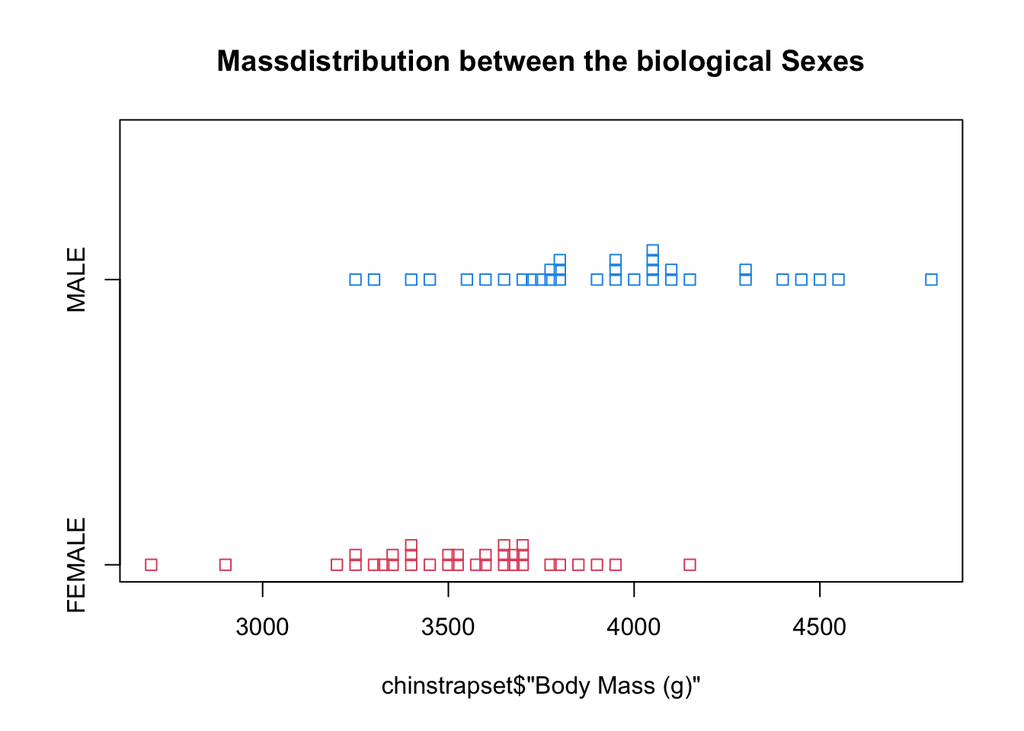

```r
stripchart(chinstrapset$"Body Mass (g)"~chinstrapset$Sex, main="Massdistribution between the biological Sexes",method="stack", col=c(2,4))
```

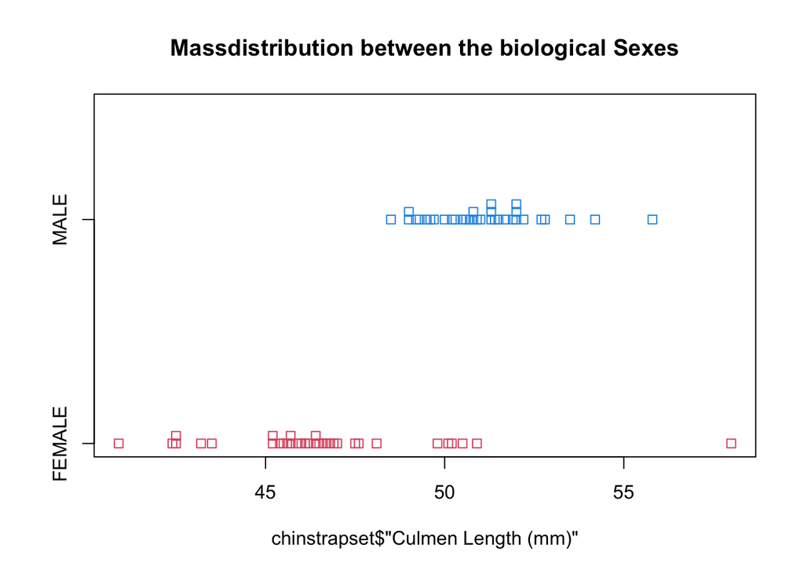

```r
stripchart(chinstrapset$"Culmen Length (mm)"~chinstrapset$Sex, main="Massdistribution between the biological Sexes",method="stack", col=c(2,4))
```

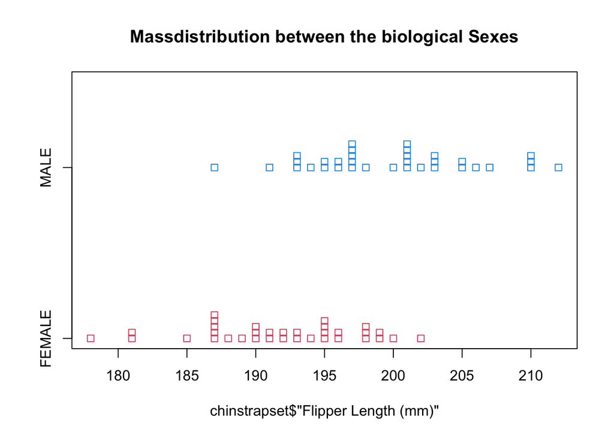

```r
stripchart(chinstrapset$"Flipper Length (mm)"~chinstrapset$Sex, main="Massdistribution between the biological Sexes",method="stack", col=c(2,4))
```

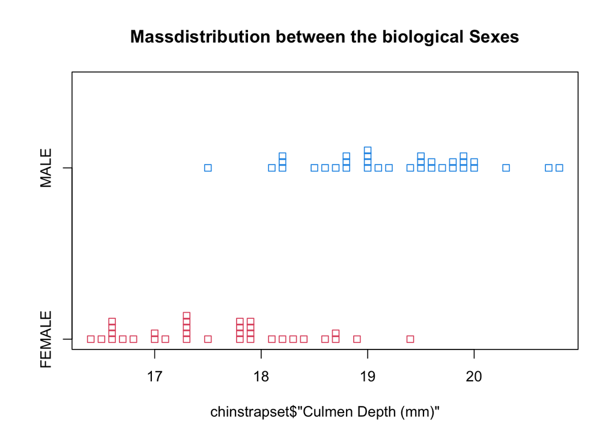

```r
stripchart(chinstrapset$"Culmen Depth (mm)"~chinstrapset$Sex, main="Massdistribution between the biological Sexes",method="stack", col=c(2,4))
```

### Histograms bodyweight

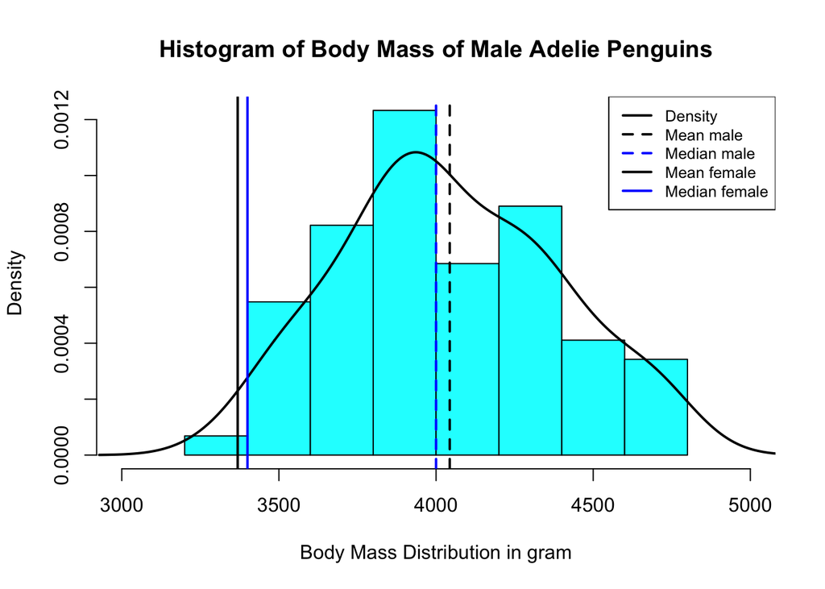

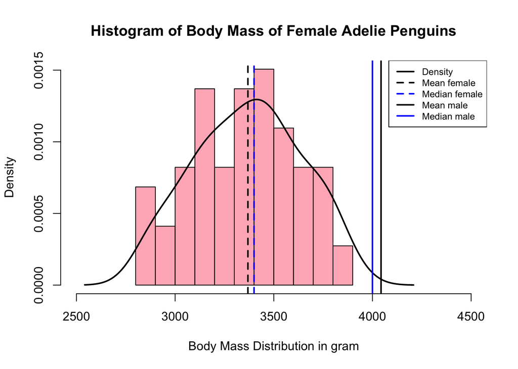

## Bodymass Chinstrap

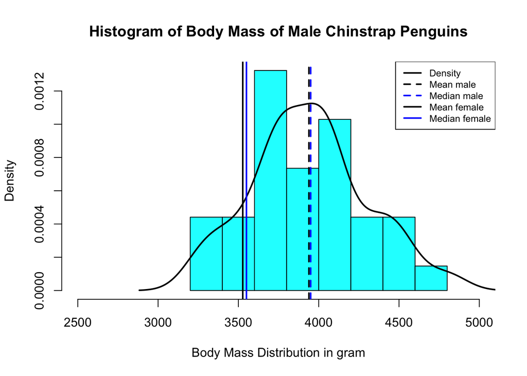

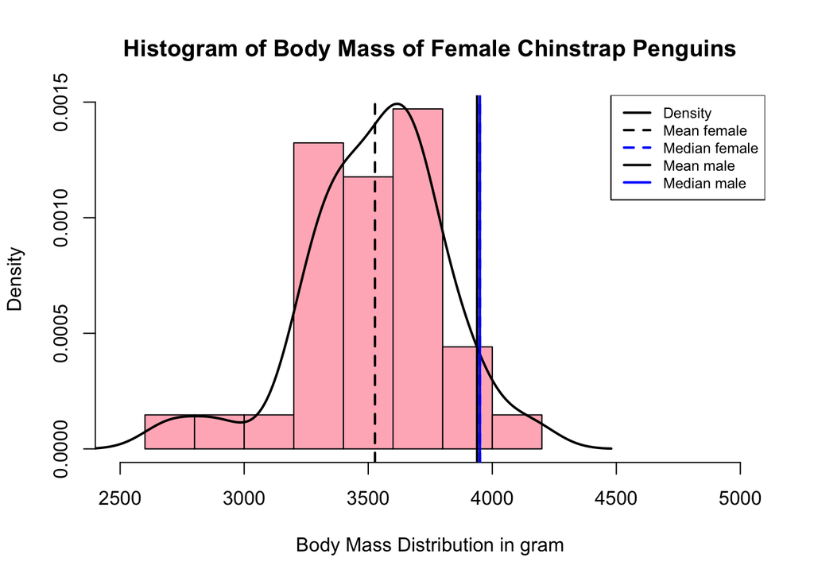

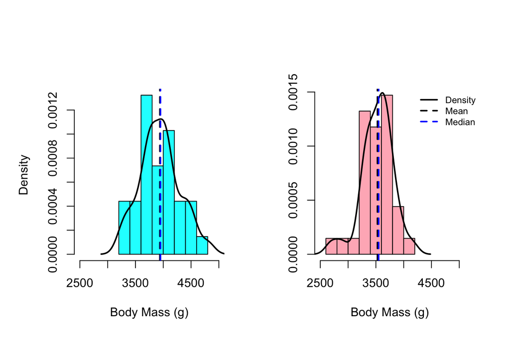

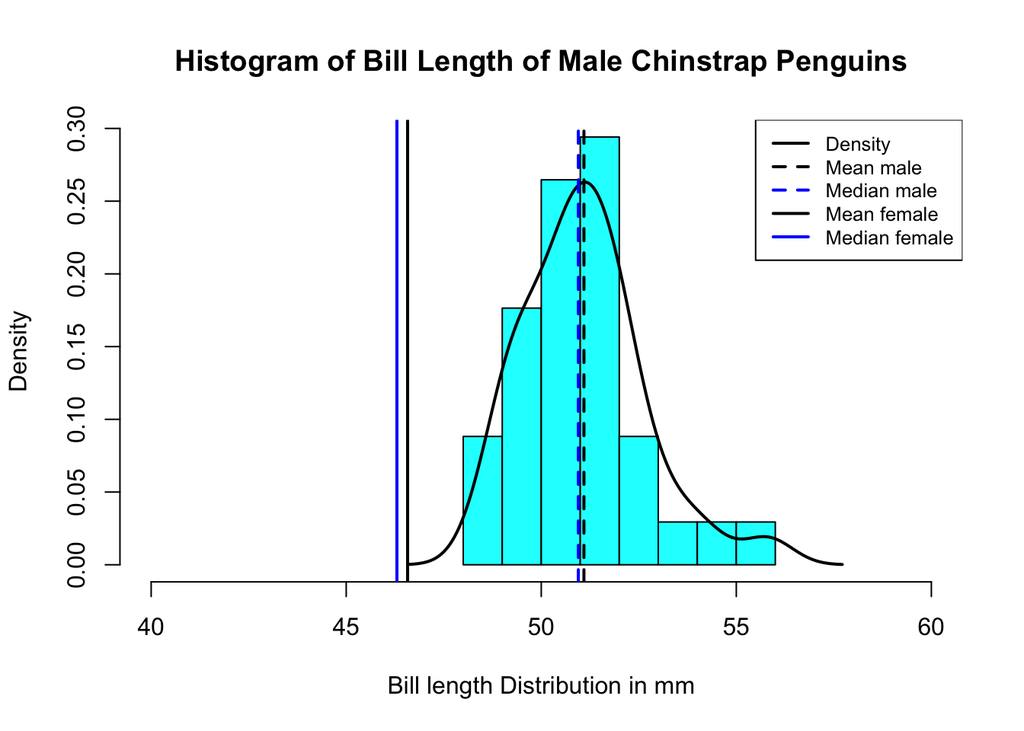

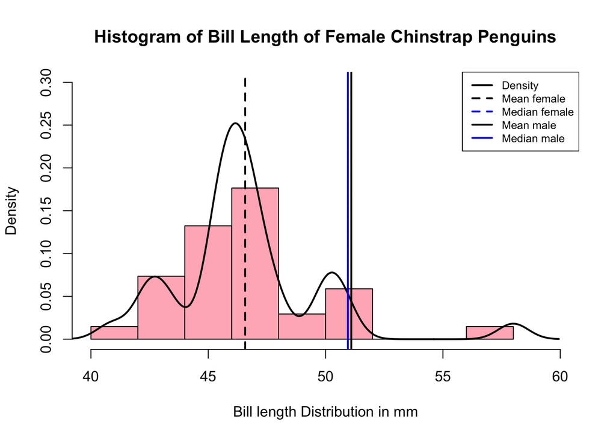

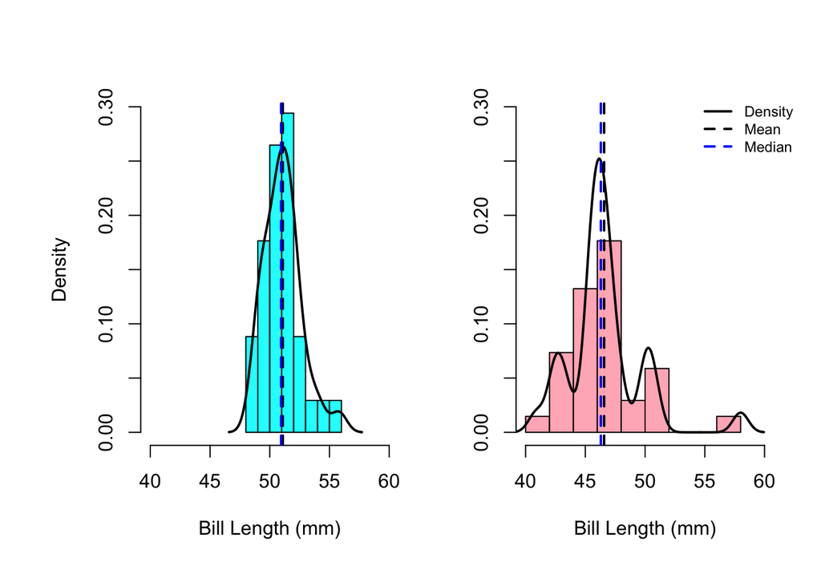

### Histogram bill depth

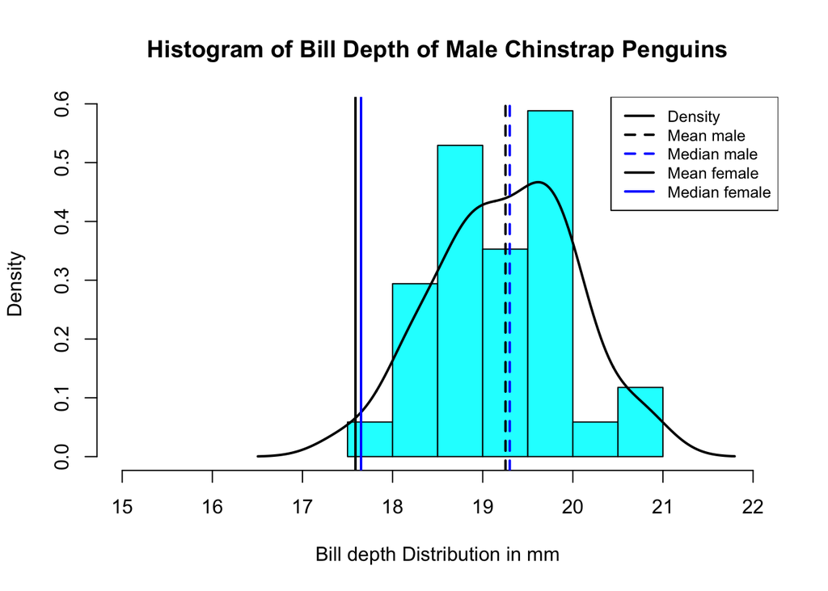

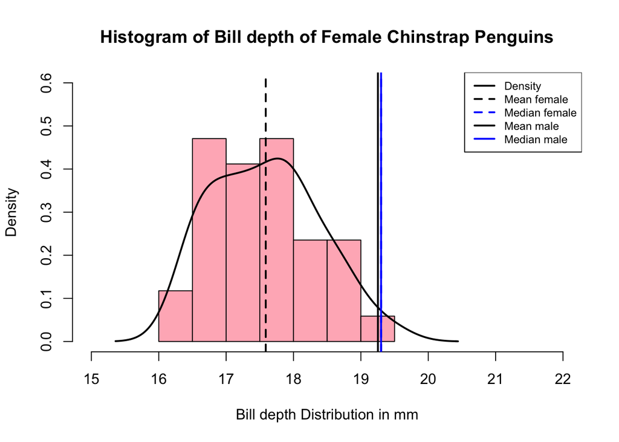

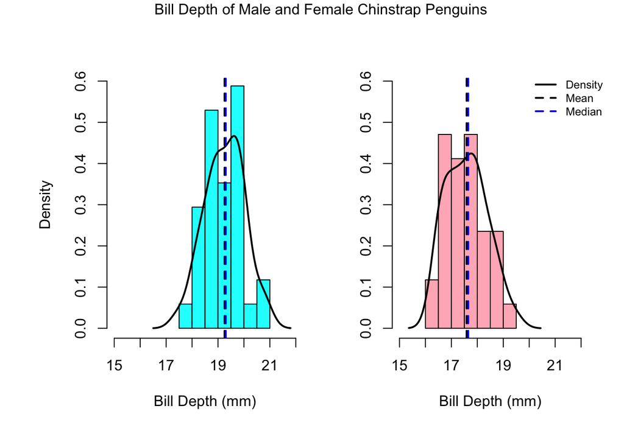

## Histogram flipperlength

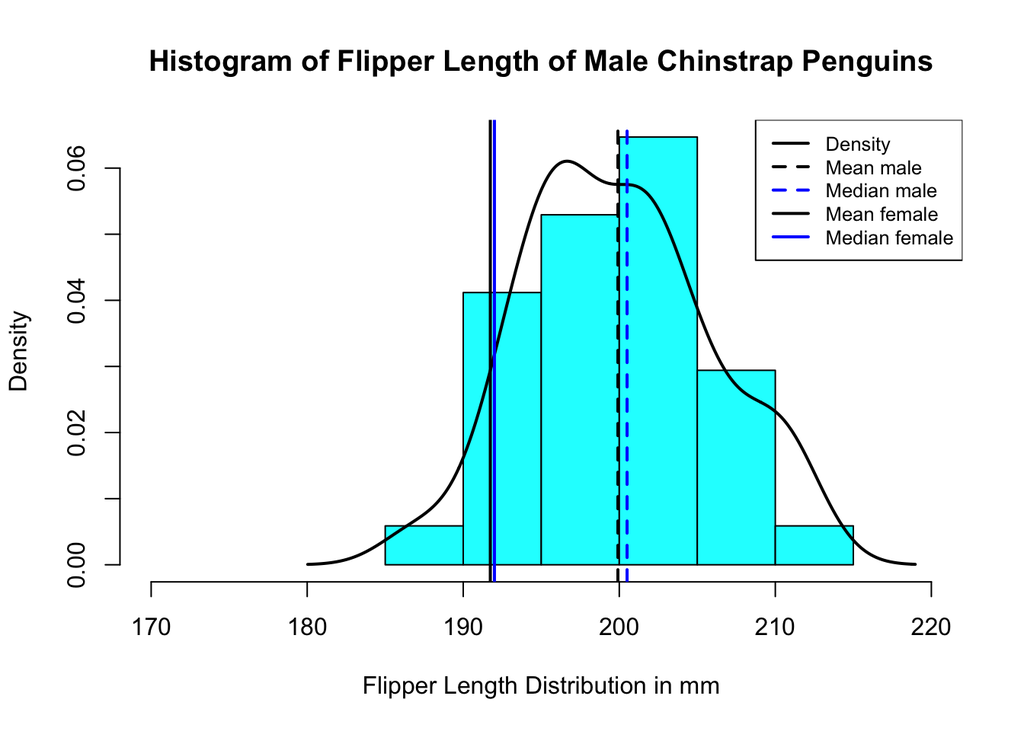

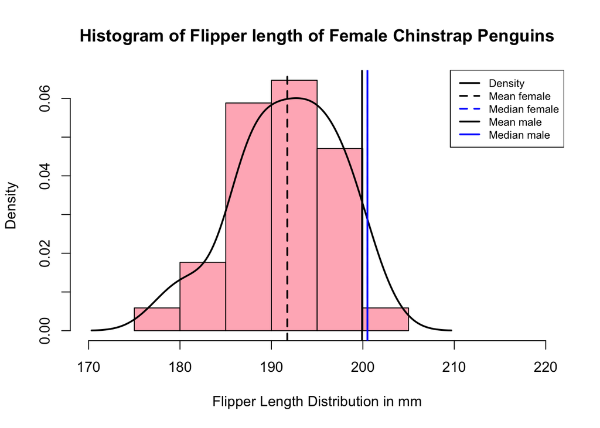

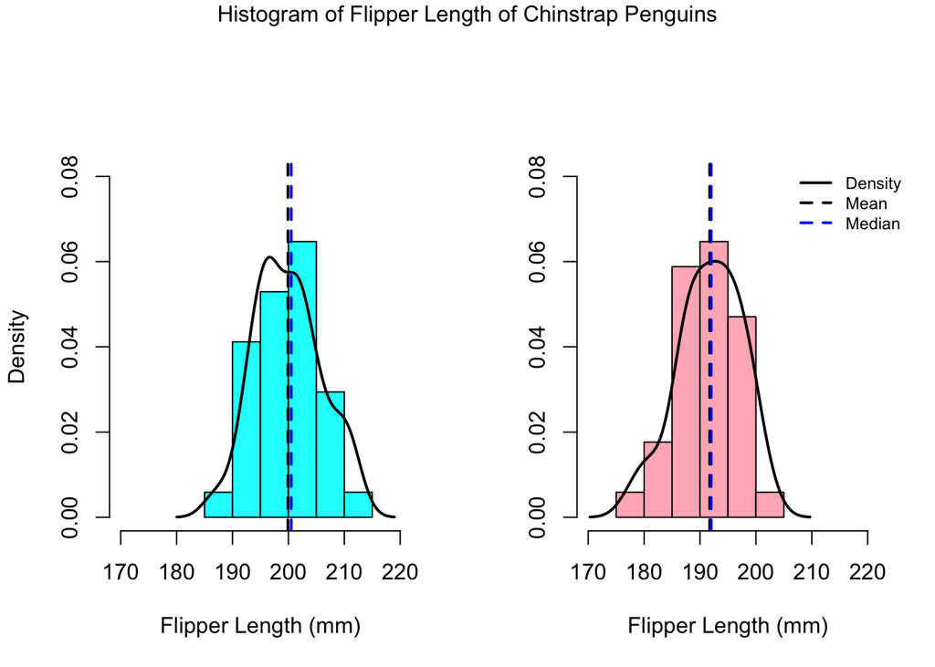